[Cancer Systems Biology](https://jiantaoshi.github.io/index.html)

# Multiple sequence alignment

## Introduction

**Multiple sequence alignment** ([MSA](https://en.wikipedia.org/wiki/Multiple_sequence_alignment)) may refer to the process or the result of sequence alignment of three or more biological sequences, generally protein, DNA, or RNA. In many cases, the input set of query sequences are assumed to have an evolutionary relationship by which they share a linkage and are descended from a common ancestor.

MSAs require more sophisticated methodologies than pairwise alignment because they are more computationally complex. Most multiple sequence alignment programs use heuristic methods rather than global optimization because identifying the optimal alignment between more than a few sequences of moderate length is prohibitively computationally expensive.

## example data

```r
library("msa")
library("ggmsa")
library("ggplot2")
library("seqinr")
library("ape")

mySequenceFile <- system.file("examples", "exampleAA.fasta", package="msa")
mySequences <- readAAStringSet(mySequenceFile)
mySequences
```

```
AAStringSet object of length 9:
    width seq                                               names
[1]   452 MSTAVLENPGLGRKLSDFGQETS...LKILADSINSEIGILCSALQKIK PH4H_Homo_sapiens
[2]   453 MAAVVLENGVLSRKLSDFGQETS...KILADSINSEVGILCNALQKIKS PH4H_Rattus_norve...
[3]   453 MAAVVLENGVLSRKLSDFGQETS...KILADSINSEVGILCHALQKIKS PH4H_Mus_musculus
[4]   297 MNDRADFVVPDITTRKNVGLSHD...DVAPDDLVLNAGDRQGWADTEDV PH4H_Chromobacter...
[5]   262 MKTTQYVARQPDDNGFIHYPETE...MALVHEAMRLGLHAPLFPPKQAA PH4H_Pseudomonas_...
[6]   451 MSALVLESRALGRKLSDFGQETS...LKILADSISSEVEILCSALQKLK PH4H_Bos_taurus
[7]   313 MAIATPTSAAPTPAPAGFTGTLT...DVVDGDAVLNAGTREGWADTADI PH4H_Ralstonia_so...
[8]   294 MSGDGLSNGPPPGARPDWTIDQG...AVLTRGTQAYATAGGRLAGAAAG PH4H_Caulobacter_...
[9]   275 MSVAEYARDCAAQGLRGDYSVCR...QTADFEAIVARRKDQKALDPATV PH4H_Rhizobium_loti
```

## Progressive alignment construction

The most widely used approach to multiple sequence alignments uses a heuristic search known as progressive technique (also known as the hierarchical or tree method) developed by Da-Fei Feng and Doolittle in 1987. Progressive alignment builds up a final MSA by combining pairwise alignments beginning with the most similar pair and progressing to the most distantly related. All progressive alignment methods require two stages: a first stage in which the relationships between the sequences are represented as a tree, called a guide tree, and a second step in which the MSA is built by adding the sequences sequentially to the growing MSA according to the guide tree. The initial guide tree is determined by an efficient clustering method such as neighbor-joining or UPGMA. The most popular progressive alignment method has been the Clustal family, especially the weighted variant ClustalW.

### ClustalW

```r
myAlignment = msaClustalW(mySequences, cluster="nj", gapOpening=10, gapExtension=0.2, maxiters=16, substitutionMatrix="blosum")
```

```
use matrix from file: blosum
```

```r
myAlignment
```

```
CLUSTAL 2.1

Call:
   msaClustalW(mySequences, cluster = "nj", gapOpening = 10, gapExtension = 0.2,     maxiters = 16, substitutionMatrix = "blosum")

MsaAAMultipleAlignment with 9 rows and 456 columns
    aln                                                    names
[1] MAAVVLENGVLSRKLSDFGQETSYIE...QLKILADSINSEVGILCNALQKIKS PH4H_Rattus_norve...
[2] MAAVVLENGVLSRKLSDFGQETSYIE...QLKILADSINSEVGILCHALQKIKS PH4H_Mus_musculus
[3] MSTAVLENPGLGRKLSDFGQETSYIE...QLKILADSINSEIGILCSALQKIK- PH4H_Homo_sapiens
[4] MSALVLESRALGRKLSDFGQETSYIE...QLKILADSISSEVEILCSALQKLK- PH4H_Bos_taurus
[5] --------------------------...LNAGDRQGWADTEDV---------- PH4H_Chromobacter...
[6] --------------------------...LNAGTREGWADTADI---------- PH4H_Ralstonia_so...
[7] --------------------------...LTRGTQAYATAGGRLAGAAAG---- PH4H_Caulobacter_...
[8] --------------------------...------------------------- PH4H_Pseudomonas_...
[9] --------------------------...------------------------- PH4H_Rhizobium_loti
Con --------------------------...??????????????I???A??---- Consensus
```

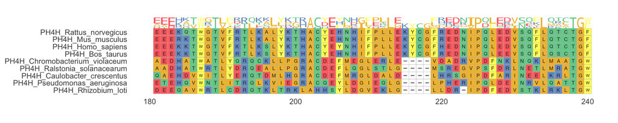

```r
myAlignment2 <- msaConvert(myAlignment, type="seqinr::alignment")
myAlignmentFile = "course/data/PH4H_aligned.fasta"
write.fasta(as.list(myAlignment2$seq), myAlignment2$nam, file = myAlignmentFile, as.string = TRUE)
ggmsa(myAlignmentFile, 181, 240, char_width = 0.5, color = "Chemistry_AA", seq_name = T) + geom_seqlogo(color = "Chemistry_AA")
```

A concensus view can also be shown.

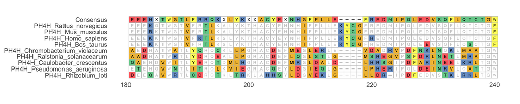

```r
ggmsa(myAlignmentFile, 181, 240, char_width = 0.5, color = "Chemistry_AA", seq_name = T, consensus_views = TRUE)
```

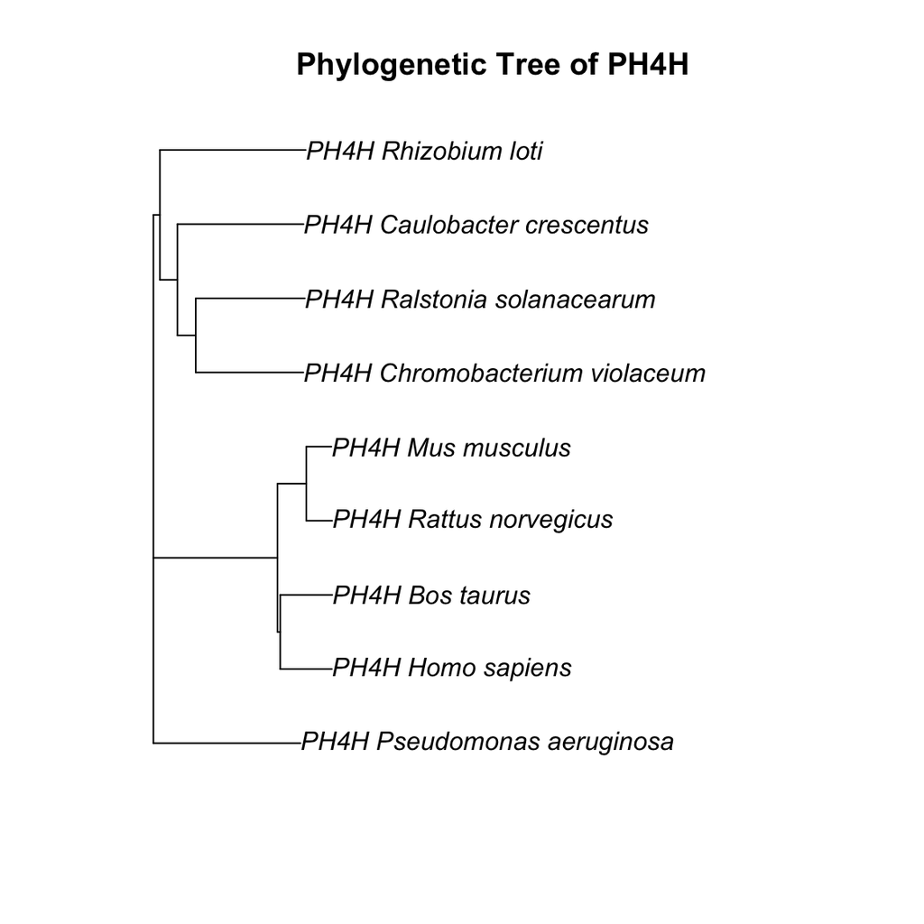

```r
d <- dist.alignment(myAlignment2, "identity")
Tree <- nj(d)
plot(Tree, main="Phylogenetic Tree of PH4H")
```

Shanghai Institute of Biochemistry and Cell Biology, Center for Excellence in Molecular Cell Science, CAS